# Foundational concepts

One-line Monte Carlo simulation

Ian Hussey

05 March, 2025

# Citation & License

Citation:

Ian Hussey (2024) Improving your statistical inferences through simulation studies in R. https://github.com/ianhussey/simulation-course

License:

[CC BY 4.0](https://creativecommons.org/licenses/by/4.0/deed.en)

# One line Monte Carlo simulation

Answering the question “what is the distribution of *p*-values under the null hypothesis?”

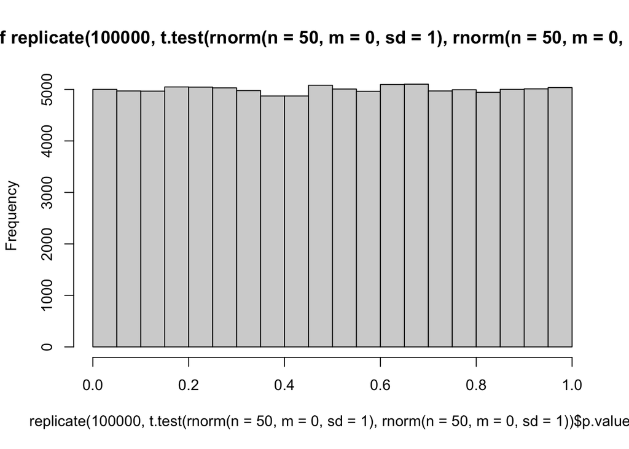

```r
set.seed(42)

hist(replicate(100000, t.test(rnorm(n = 50, m = 0, sd = 1), rnorm(n = 50, m = 0, sd = 1))$p.value))
```

This is a complete Monte Carlo simulation. But how is it constructed? Let’s built it up more slowly.

# Generate normally distributed data

Draw data from a normally distributed population and plot it using `rnorm()`

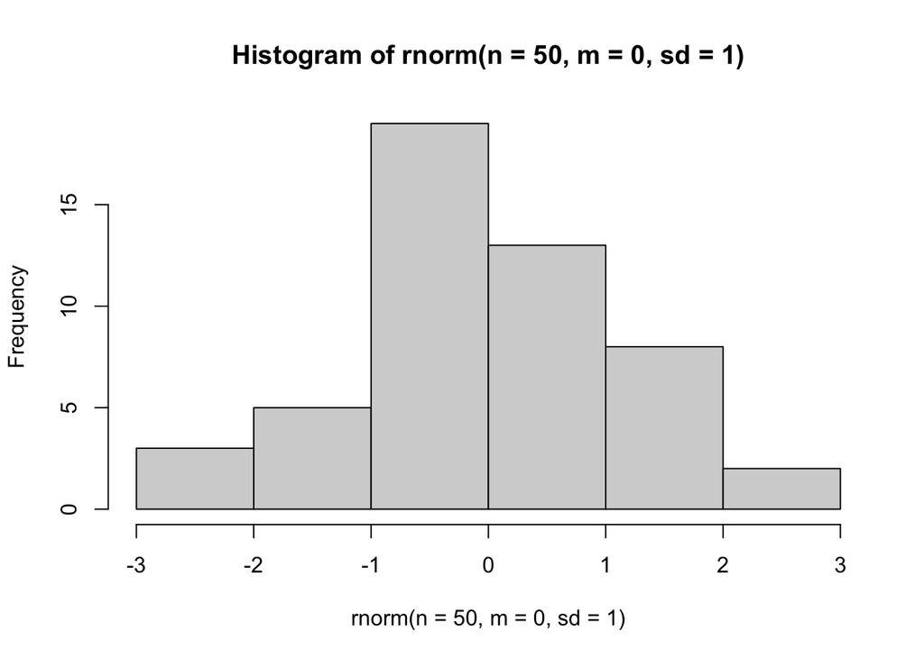

```r
set.seed(42)

rnorm(n = 50, m = 0, sd = 1) |>
  hist()
```

# Generate two normally distributed data sets and fit a *t*-test

Note the population means are equivalent. What does a *t*-test test for?

```r
set.seed(42)

t.test(rnorm(n = 50, m = 0, sd = 1),
       rnorm(n = 50, m = 0, sd = 1))
```

```
##
##  Welch Two Sample t-test
##
## data:  rnorm(n = 50, m = 0, sd = 1) and rnorm(n = 50, m = 0, sd = 1)
## t = -0.65289, df = 93.647, p-value = 0.5154
## alternative hypothesis: true difference in means is not equal to 0
## 95 percent confidence interval:
##  -0.5511248  0.2783784
## sample estimates:
##   mean of x   mean of y
## -0.03567178  0.10070141
```

# Generate two normally distributed data sets and fit a *t*-test and extract the *p*-value

```r
set.seed(42)

t.test(rnorm(n = 50, m = 0, sd = 1), rnorm(n = 50, m = 0, sd = 1))$p.value
```

```
## [1] 0.5154295
```

# Do this generate-analyze-extract many times

Using the `replicate()` function, and plot the *p*-values using `hist()`.

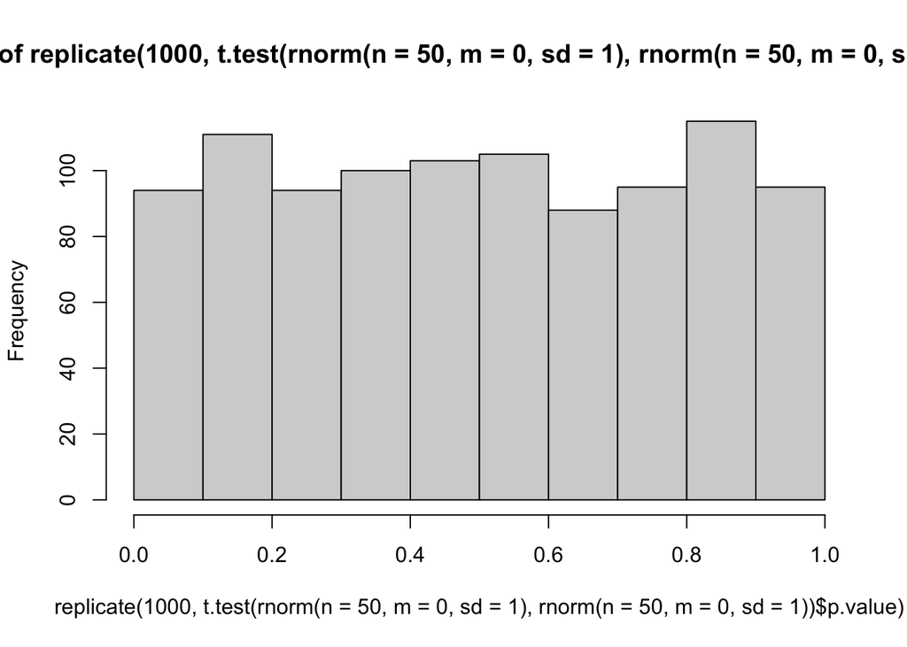

```r
set.seed(42)

hist(replicate(1000, t.test(rnorm(n = 50, m = 0, sd = 1), rnorm(n = 50, m = 0, sd = 1))$p.value))
```

# Increase the number of iterations

Why is the distribution more uniform?

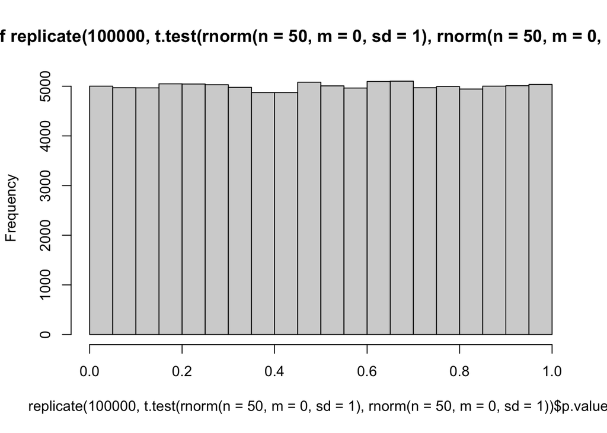

```r
set.seed(42)

hist(replicate(100000, t.test(rnorm(n = 50, m = 0, sd = 1), rnorm(n = 50, m = 0, sd = 1))$p.value))
```

# Compare with distribution of *p*-values when population means are not equal

‘Small’, ‘medium’ and ‘large’ differences in population means.

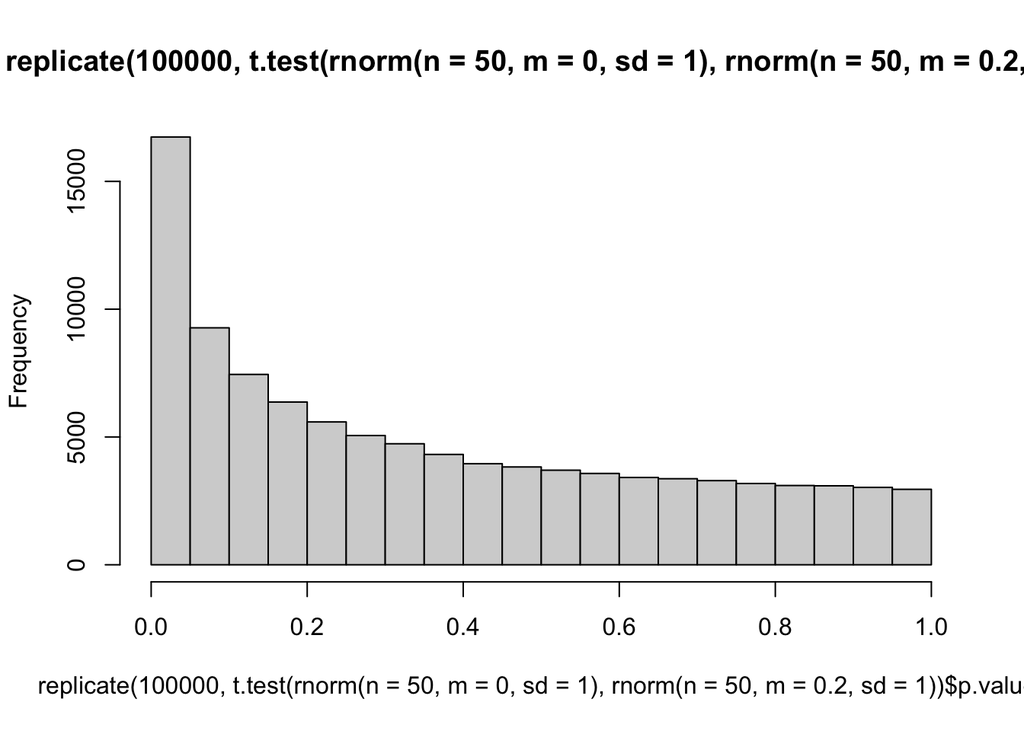

```r
set.seed(42)

hist(replicate(100000, t.test(rnorm(n = 50, m = 0, sd = 1), rnorm(n = 50, m = 0.2, sd = 1))$p.value))
```

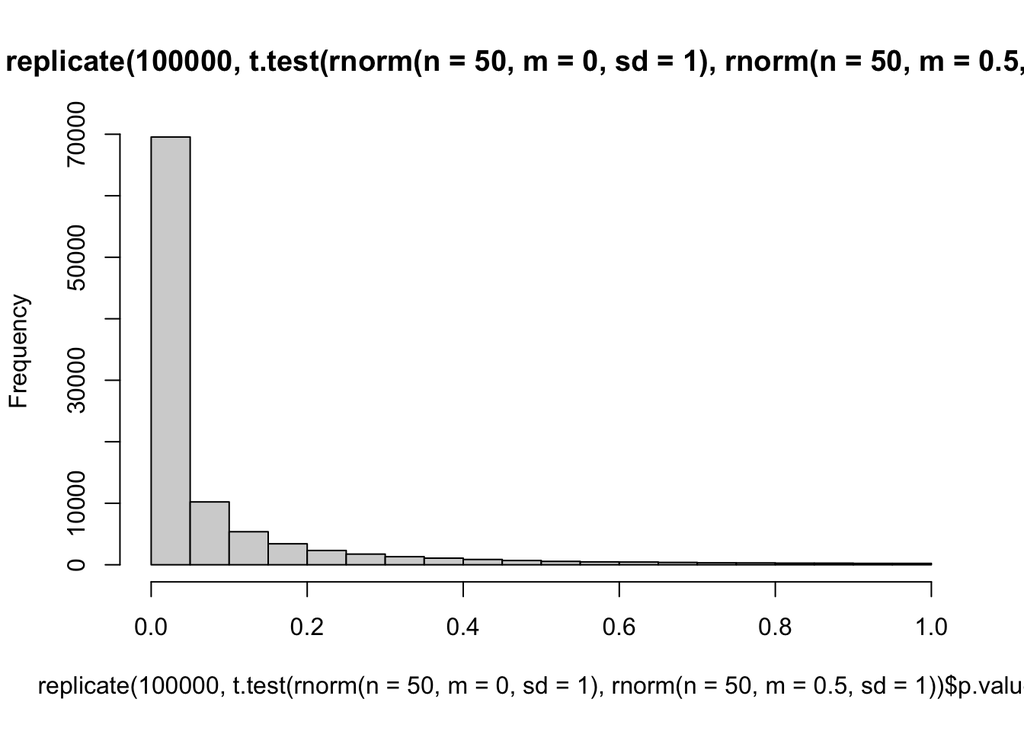

```r
hist(replicate(100000, t.test(rnorm(n = 50, m = 0, sd = 1), rnorm(n = 50, m = 0.5, sd = 1))$p.value))
```

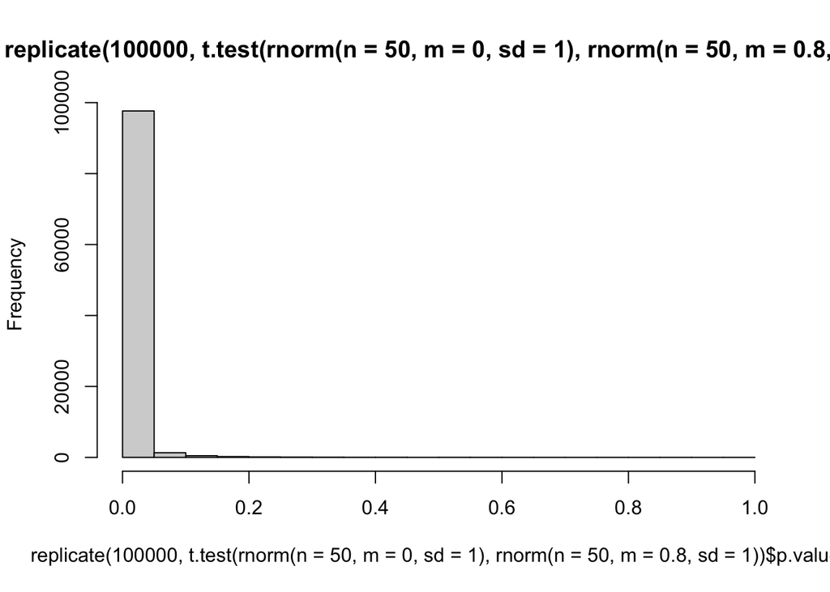

```r
hist(replicate(100000, t.test(rnorm(n = 50, m = 0, sd = 1), rnorm(n = 50, m = 0.8, sd = 1))$p.value))
```

# Check your learning

- What are the five core components of a Monte Carlo simulation?
- Can you mentally match these five components onto the above code (sometimes in different chunks!) to understand how, together, they answer the question “what is the distribution of *p*-values under the null vs. alternative hypothesis?”